# Impact of Federal Reserve Rate Cuts on Economic Indicators

### Correlation Analysis

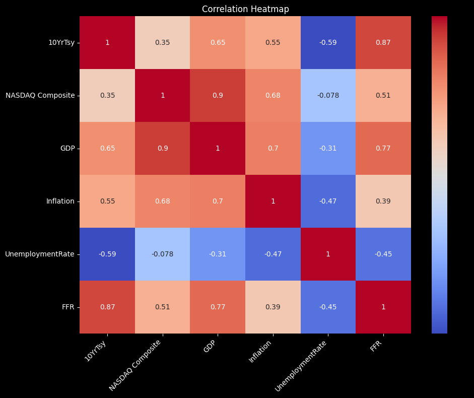

```python
data.index = pd.to_datetime(data.index)
corr_matrix = data.corr()
fig, ax = plt.subplots(figsize=(10, 8))
fig.patch.set_facecolor('black')

sns.heatmap(corr_matrix, annot=True, cmap='coolwarm', ax=ax, cbar=True)
ax.set_title('Correlation Heatmap', color='white')
ax.tick_params(colors='white')
for spine in ax.spines.values():
    spine.set_edgecolor('white')

plt.setp(ax.get_xticklabels(), rotation=45, ha="right", color='white')
plt.setp(ax.get_yticklabels(), rotation=0, color='white')

plt.tight_layout()
plt.show()
```

- Economic Growth and the Stock Market: The strong positive correlation between GDP and the NASDAQ Composite suggests that stock market performance is closely tied to economic growth. As GDP rises, so does investor confidence, which tends to boost stock prices.
- Inflation and Unemployment: The negative correlation between inflation and the unemployment rate reflects the traditional Phillips Curve theory. According to this theory, there is an inverse relationship between inflation and unemployment in the short run. When inflation rises, it usually signals an economy with strong demand, prompting businesses to hire more workers, which lowers unemployment. Conversely, when inflation is low, it may indicate weaker demand, leading to higher unemployment as businesses scale back hiring. This theory aligns with the observed data, where periods of higher inflation are associated with lower unemployment rates.
- Federal Funds Rate and Treasury Yields: The strong positive correlation between the Federal Funds Rate (FFR) and the 10-Year Treasury Yield indicates that changes in the Fed's rate-setting policies directly influence long-term interest rates. As the Fed raises or lowers the FFR, Treasury yields tend to follow, impacting borrowing costs across the economy, which in turn affects investment decisions and economic growth.
- Mixed Impact of Fed Rates on the NASDAQ: The moderate positive correlation between the FFR and the NASDAQ Composite suggests that rate changes by the Fed do influence investor behavior, though not as strongly as economic growth does. While lower interest rates generally stimulate investment in stocks, other factors, such as GDP growth and inflation expectations, play a more significant role in driving stock market performance.